# AllLife Credit Card Customer Segmentation

## Background:

AllLife Bank wants to focus on its credit card customer base in the next financial year. They have been advised by their marketing research team, that the penetration in the market can be improved. Based on this input, the Marketing team proposes to run personalised campaigns to target new customers as well as upsell to existing customers. Another insight from the market research was that the customers perceive the support services of the back poorly. Based on this, the Operations team wants to upgrade the service delivery model, to ensure that customers queries are resolved faster. Head of Marketing and Head of Delivery both decide to reach out to the Data Science team for help.

## Objective: To identify different segments in the existing customer based on their spending patterns as well as past interaction with the bank.

### Key Questions:

- 1. How many different segments of customers are there?
- 1. How are these segments different from each other?
- 1. What are your recommendations to the bank on how to better market to and service these customers?

### Data Description:

Data is of various customers of a bank with their credit limit, the total number of credit cards the customer has, and different channels through which customer has contacted the bank for any queries, different channels include visiting the bank, online and through a call centre

Steps to follow:

- 1. Perform univariate analysis on the data to better understand the variables at your disposal and to get an idea about the no of clusters.
- 1. Perform EDA and take insights out. pts 1 and 2 – (5)
- 1. Create visualizations to explore data and present the insights. (5)
- 1. Properly comment on the codes and provide explanations of the steps taken in the notebook. (5)
- 1. Execute hierarchical and K-means clustering (with different linkages) and do relevant visualisations (elbow plot, dendrograms etc) (10)
- 1. Perform a silhouette analysis. (5)

```python
import warnings
warnings.filterwarnings('ignore')
```

```python
import pandas as pd
import numpy as np
import matplotlib.pyplot as plt
%matplotlib inline
# To enable plotting graphs in Jupyter notebook
import seaborn as sns

from sklearn.metrics import silhouette_score

# Remove scientific notations and display numbers with 2 decimal points instead
pd.options.display.float_format = '{:,.2f}'.format
sns.set_style('whitegrid')
```

```python
#Load the file from local directory using pd.read_csv which is a special form of read_table
cc_df = pd.read_excel("Credit Card Customer Data.xlsx", index_col='Sl_No')
cc_df.head()
```

| Sl_No | Customer Key | Avg_Credit_Limit | Total_Credit_Cards | Total_visits_bank | Total_visits_online | Total_calls_made |
| --- | --- | --- | --- | --- | --- | --- |
| 1 | 87073 | 100000 | 2 | 1 | 1 | 0 |
| 2 | 38414 | 50000 | 3 | 0 | 10 | 9 |
| 3 | 17341 | 50000 | 7 | 1 | 3 | 4 |
| 4 | 40496 | 30000 | 5 | 1 | 1 | 4 |
| 5 | 47437 | 100000 | 6 | 0 | 12 | 3 |

```python
cc_df.shape
```

```
(660, 6)
```

```python
cc_df.info()
```

```
<class 'pandas.core.frame.DataFrame'>
Int64Index: 660 entries, 1 to 660
Data columns (total 6 columns):
 #   Column               Non-Null Count  Dtype
---  ------               --------------  -----
 0   Customer Key         660 non-null    int64
 1   Avg_Credit_Limit     660 non-null    int64
 2   Total_Credit_Cards   660 non-null    int64
 3   Total_visits_bank    660 non-null    int64
 4   Total_visits_online  660 non-null    int64
 5   Total_calls_made     660 non-null    int64
dtypes: int64(6)
memory usage: 36.1 KB
```

```python
cc_df.isna().sum()
```

```
Customer Key           0
Avg_Credit_Limit       0
Total_Credit_Cards     0
Total_visits_bank      0
Total_visits_online    0
Total_calls_made       0
dtype: int64
```

```python
cc_df.describe().T
```

|  | count | mean | std | min | 25% | 50% | 75% | max |
| --- | --- | --- | --- | --- | --- | --- | --- | --- |
| Customer Key | 660.00 | 55,141.44 | 25,627.77 | 11,265.00 | 33,825.25 | 53,874.50 | 77,202.50 | 99,843.00 |
| Avg_Credit_Limit | 660.00 | 34,574.24 | 37,625.49 | 3,000.00 | 10,000.00 | 18,000.00 | 48,000.00 | 200,000.00 |
| Total_Credit_Cards | 660.00 | 4.71 | 2.17 | 1.00 | 3.00 | 5.00 | 6.00 | 10.00 |
| Total_visits_bank | 660.00 | 2.40 | 1.63 | 0.00 | 1.00 | 2.00 | 4.00 | 5.00 |
| Total_visits_online | 660.00 | 2.61 | 2.94 | 0.00 | 1.00 | 2.00 | 4.00 | 15.00 |
| Total_calls_made | 660.00 | 3.58 | 2.87 | 0.00 | 1.00 | 3.00 | 5.00 | 10.00 |

```python
# Customer Key - should be unique - not part of analysis
multi_customer_key  = cc_df['Customer Key'].value_counts()
multi_customer_key = multi_customer_key[multi_customer_key> 1].index.to_list()
cc_df[cc_df['Customer Key'].isin(multi_customer_key)].sort_values(by='Customer Key')
```

| Sl_No | Customer Key | Avg_Credit_Limit | Total_Credit_Cards | Total_visits_bank | Total_visits_online | Total_calls_made |
| --- | --- | --- | --- | --- | --- | --- |
| 49 | 37252 | 6000 | 4 | 0 | 2 | 8 |
| 433 | 37252 | 59000 | 6 | 2 | 1 | 2 |
| 5 | 47437 | 100000 | 6 | 0 | 12 | 3 |
| 333 | 47437 | 17000 | 7 | 3 | 1 | 0 |
| 412 | 50706 | 44000 | 4 | 5 | 0 | 2 |
| 542 | 50706 | 60000 | 7 | 5 | 2 | 2 |
| 392 | 96929 | 13000 | 4 | 5 | 0 | 0 |
| 399 | 96929 | 67000 | 6 | 2 | 2 | 2 |
| 105 | 97935 | 17000 | 2 | 1 | 2 | 10 |
| 633 | 97935 | 187000 | 7 | 1 | 7 | 0 |

### We found few records with same Customer Key

- we can drop them all - its only 10 records
- we can replace them by average
- we can drop one out of each group
- 49 - Total_Calls_made on the max side - we can drop it
- 5 - Total_visits_online on the max side - we can drop it
- 542 - Totdal calls and cards on the higher side - we can drop it
- 392 - Two zeros we drop it
- 105 - Total_calls_made on the high side we drop it

```python
#drop
cc_df.drop([49,5,542,392,105],inplace=True, axis =0)

#drop customer_key
cc_df.drop(['Customer Key'],inplace=True, axis =1)
cc_df.shape
```

```
(655, 5)
```

```python
#Adding Total Credit -> limit * cc
cc_df['Total_Credit']= cc_df.Avg_Credit_Limit * cc_df.Total_Credit_Cards
cols_numeric = ['Avg_Credit_Limit','Total_Credit_Cards','Total_visits_bank','Total_visits_bank','Total_visits_online','Total_calls_made','Total_Credit']
```

```python
def show_plots(df, features):
    for feature in features:
        print(f'***   {feature}      ***')
        print( df[feature].describe())
        fig, (ax1, ax2) = plt.subplots(1,2, figsize = (24, 6))
        sns.boxplot(df[feature], ax = ax1)
        plt.title(feature)
        if feature in [ 'Avg_Credit_Limit','Total_Credit']:
            sns.distplot(df[feature], kde = True, ax= ax2, rug=True)
            plt.axvline(df[feature].mean(),linestyle="dashed",label="mean")
            plt.legend(loc="best")
        else:
            sns.countplot(df[feature] ,ax= ax2)
        plt.title(feature)
        plt.show()
        yield

feature_analysis = iter(show_plots(cc_df,cols_numeric ))
```

```
***   Avg_Credit_Limit      ***
count       655.00
mean     34,538.93
std      37,636.86
min       3,000.00
25%      10,000.00
50%      18,000.00
75%      48,000.00
max     200,000.00
Name: Avg_Credit_Limit, dtype: float64
```

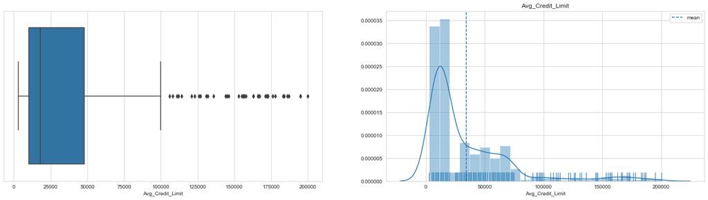

```python
next(feature_analysis)

# Majority Credit limit below 18000
# However for credit limit > 18000, the range is much more ( 18000-200000) has 50% data
```

```
***   Total_Credit_Cards      ***
count   655.00
mean      4.71
std       2.17
min       1.00
25%       3.00
50%       5.00
75%       6.00
max      10.00
Name: Total_Credit_Cards, dtype: float64
```

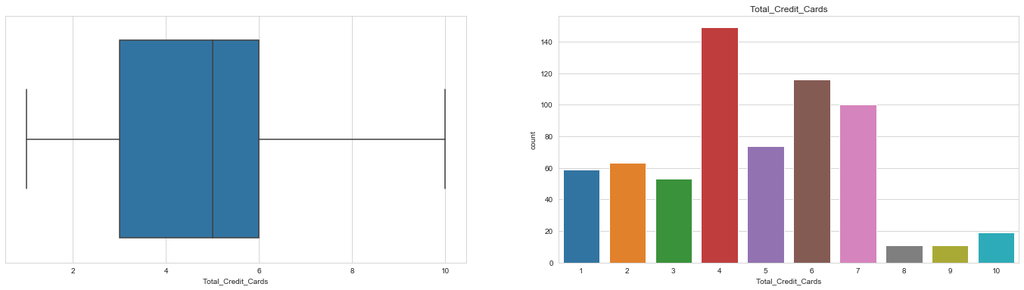

```python
next(feature_analysis)
## very few people with more than >= 8
```

```
***   Total_visits_bank      ***
count   655.00
mean      2.40
std       1.63
min       0.00
25%       1.00
50%       2.00
75%       4.00
max       5.00
Name: Total_visits_bank, dtype: float64
```

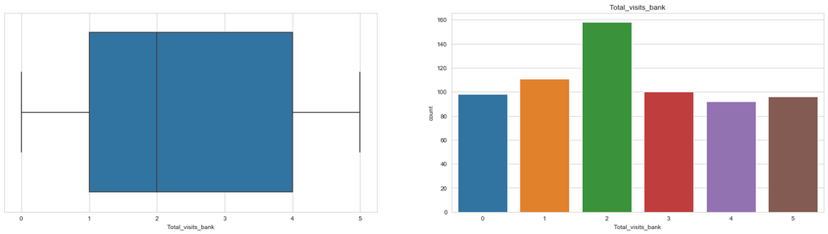

```python
next(feature_analysis)

## total visits equally distributed
```

```
***   Total_visits_bank      ***
count   655.00
mean      2.40
std       1.63
min       0.00
25%       1.00
50%       2.00
75%       4.00
max       5.00
Name: Total_visits_bank, dtype: float64
```

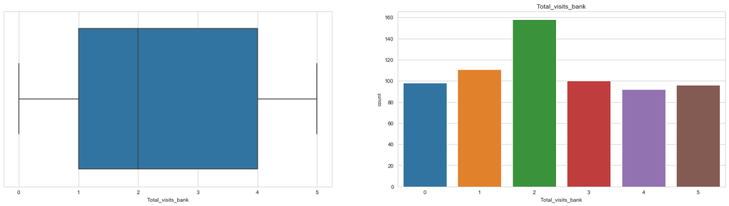

```python
next(feature_analysis)
```

```
***   Total_visits_online      ***
count   655.00
mean      2.60
std       2.92
min       0.00
25%       1.00
50%       2.00
75%       4.00
max      15.00
Name: Total_visits_online, dtype: float64
```

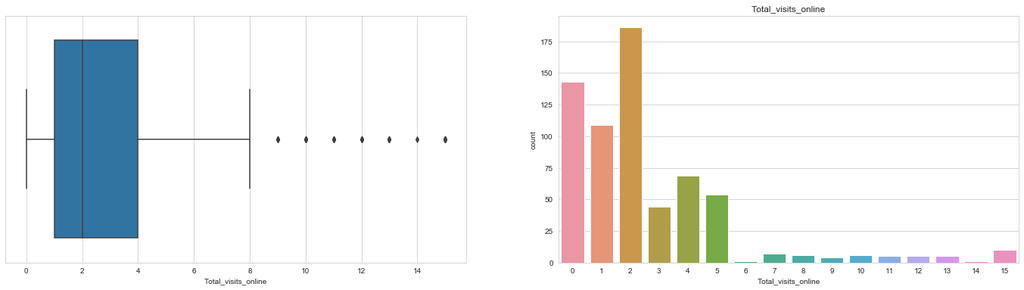

```python
next(feature_analysis)

# very few online visits  >=6
## Max visit 15 has a small peak -> we will have to investigate later
```

```
***   Total_calls_made      ***
count   655.00
mean      3.58
std       2.86
min       0.00
25%       1.00
50%       3.00
75%       5.00
max      10.00
Name: Total_calls_made, dtype: float64
```

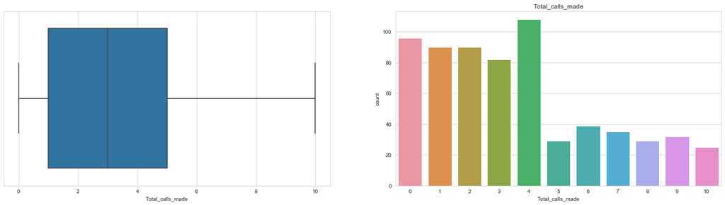

```python
next(feature_analysis)
```

```
***   Total_Credit      ***
count         655.00
mean      212,190.84
std       330,552.09
min         5,000.00
25%        33,000.00
50%        80,000.00
75%       254,000.00
max     2,000,000.00
Name: Total_Credit, dtype: float64
```

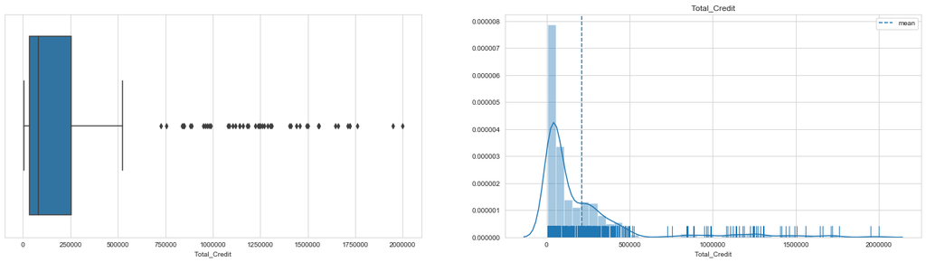

```python
next(feature_analysis)
# majority have small limits
```

- The average limit and total credit has outliers

```python
def list_outliers(df, features):
    for feature in features:
        print(f'***   {feature}      ***')
        q1 = df[feature].quantile(0.25)
        q3 = df[feature].quantile(0.75)
        IQR = q3 - q1
        print( f'IQR: {IQR}')
        cdf = df[df[feature]> q3 + 1.5*IQR]
        print(cdf.describe())
        yield
cols_outliers  = ['Avg_Credit_Limit','Total_Credit','Total_visits_online']
list_outlier = iter(list_outliers(cc_df,cols_outliers ))
```

```python
next(list_outlier)
```

```
***   Avg_Credit_Limit      ***
IQR: 38000.0
       Avg_Credit_Limit  Total_Credit_Cards  Total_visits_bank  \
count             39.00               39.00              39.00
mean         154,205.13                8.74               0.59
std           26,715.05                1.14               0.50
min          106,000.00                7.00               0.00
25%          131,500.00                8.00               0.00
50%          157,000.00                9.00               1.00
75%          172,500.00               10.00               1.00
max          200,000.00               10.00               1.00

       Total_visits_online  Total_calls_made  Total_Credit
count                39.00             39.00         39.00
mean                 10.87              1.00  1,345,076.92
std                   2.95              0.83    283,537.00
min                   7.00              0.00    847,000.00
25%                   8.00              0.00  1,150,500.00
50%                  11.00              1.00  1,288,000.00
75%                  13.00              2.00  1,530,000.00
max                  15.00              2.00  2,000,000.00
```

```python
next(list_outlier)
```

```
***   Total_Credit      ***
IQR: 221000.0
       Avg_Credit_Limit  Total_Credit_Cards  Total_visits_bank  \
count             48.00               48.00              48.00
mean         142,750.00                8.88               0.62
std           34,105.91                1.10               0.49
min           84,000.00                7.00               0.00
25%          111,750.00                8.00               0.00
50%          149,500.00                9.00               1.00
75%          171,250.00               10.00               1.00
max          200,000.00               10.00               1.00

       Total_visits_online  Total_calls_made  Total_Credit
count                48.00             48.00         48.00
mean                 10.88              1.02  1,257,916.67
std                   2.94              0.84    316,491.39
min                   6.00              0.00    728,000.00
25%                   8.00              0.00    988,500.00
50%                  11.00              1.00  1,243,000.00
75%                  13.00              2.00  1,468,500.00
max                  15.00              2.00  2,000,000.00
```

### We observe that customers with High Credit Limit/ High Total Credit

- Have very high online visits
- Have every high Credit Cards
- Have very little calls made and very little bank visits

```python
next(list_outlier)
```

```
***   Total_visits_online      ***
IQR: 3.0
       Avg_Credit_Limit  Total_Credit_Cards  Total_visits_bank  \
count             36.00               36.00              36.00
mean         141,055.56                8.75               0.58
std           38,058.56                1.59               0.50
min           50,000.00                3.00               0.00
25%          106,000.00                8.00               0.00
50%          145,500.00                9.00               1.00
75%          172,000.00               10.00               1.00
max          200,000.00               10.00               1.00

       Total_visits_online  Total_calls_made  Total_Credit
count                36.00             36.00         36.00
mean                 12.22              1.33  1,246,583.33
std                   2.15              1.57    399,116.55
min                   9.00              0.00    150,000.00
25%                  10.00              0.00    980,500.00
50%                  12.00              1.00  1,217,000.00
75%                  15.00              2.00  1,516,500.00
max                  15.00              9.00  2,000,000.00
```

#### People with high total credit/more credit cards/ average limit have more online visits

```python
cc_df.describe().transpose()
```

|  | count | mean | std | min | 25% | 50% | 75% | max |
| --- | --- | --- | --- | --- | --- | --- | --- | --- |
| Avg_Credit_Limit | 655.00 | 34,538.93 | 37,636.86 | 3,000.00 | 10,000.00 | 18,000.00 | 48,000.00 | 200,000.00 |
| Total_Credit_Cards | 655.00 | 4.71 | 2.17 | 1.00 | 3.00 | 5.00 | 6.00 | 10.00 |
| Total_visits_bank | 655.00 | 2.40 | 1.63 | 0.00 | 1.00 | 2.00 | 4.00 | 5.00 |
| Total_visits_online | 655.00 | 2.60 | 2.92 | 0.00 | 1.00 | 2.00 | 4.00 | 15.00 |
| Total_calls_made | 655.00 | 3.58 | 2.86 | 0.00 | 1.00 | 3.00 | 5.00 | 10.00 |
| Total_Credit | 655.00 | 212,190.84 | 330,552.09 | 5,000.00 | 33,000.00 | 80,000.00 | 254,000.00 | 2,000,000.00 |

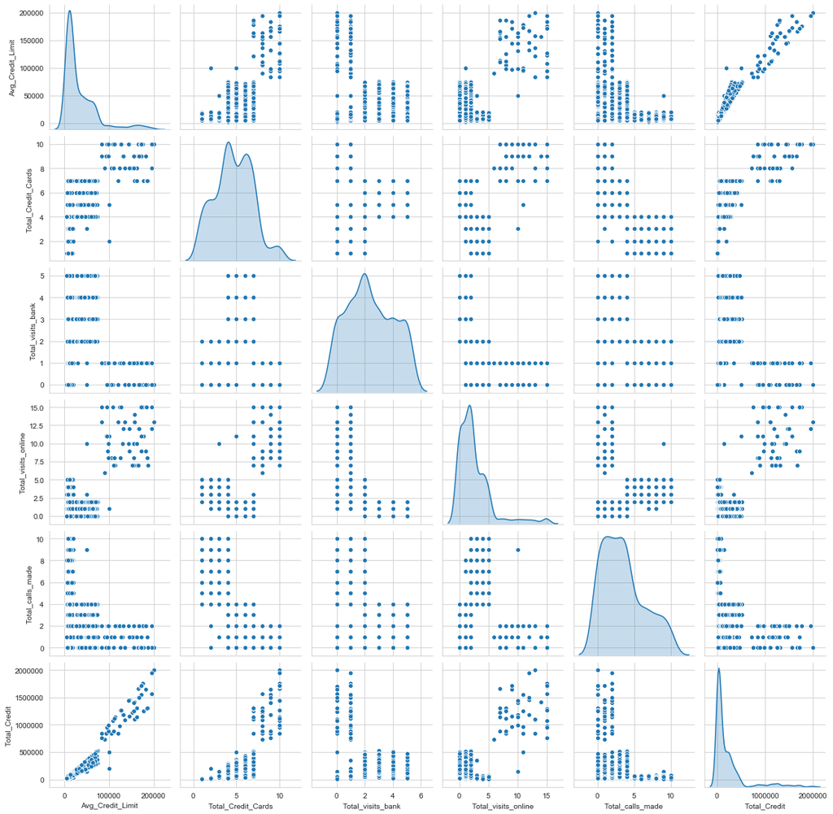

```python
sns.pairplot(cc_df, diag_kind='kde')
```

We see at least 3 clusters being well defined in a number of plots Total Credit Cards suggests upto 5 clusters

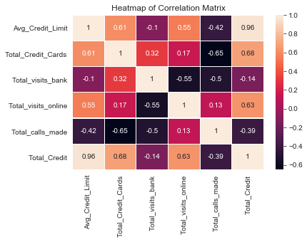

```python
# Create a correlation matrix. What features correlate the most eachpther?
corr = cc_df.corr()
sns.heatmap(corr,
            xticklabels=corr.columns.values,
            yticklabels=corr.columns.values,
            linewidths=.2,
            annot=True,
            annot_kws={"size": 10})
plt.title('Heatmap of Correlation Matrix')
```

- 1. More credit limit -> more credit cards ->less calls made
- 1. More visits online -> more Total Credit
- 1. either online or bank visit

From the pair plots we can see see that the diagnols have 5 modes and some of teh crss plots have 3 groups

```python
##Scale the data
from scipy.stats import zscore

scaled_df = cc_df.apply(zscore)
scaled_df.describe()
```

|  | Avg_Credit_Limit | Total_Credit_Cards | Total_visits_bank | Total_visits_online | Total_calls_made | Total_Credit |
| --- | --- | --- | --- | --- | --- | --- |
| count | 655.00 | 655.00 | 655.00 | 655.00 | 655.00 | 655.00 |
| mean | -0.00 | -0.00 | 0.00 | 0.00 | 0.00 | -0.00 |
| std | 1.00 | 1.00 | 1.00 | 1.00 | 1.00 | 1.00 |
| min | -0.84 | -1.71 | -1.48 | -0.89 | -1.25 | -0.63 |
| 25% | -0.65 | -0.79 | -0.86 | -0.55 | -0.90 | -0.54 |
| 50% | -0.44 | 0.14 | -0.25 | -0.20 | -0.20 | -0.40 |
| 75% | 0.36 | 0.60 | 0.98 | 0.48 | 0.50 | 0.13 |
| max | 4.40 | 2.44 | 1.60 | 4.25 | 2.25 | 5.41 |

# KMeans

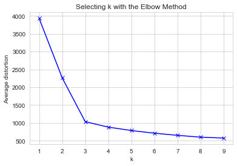

```python
#Finding optimal no. of clusters
from scipy.spatial.distance import cdist
from sklearn.cluster import KMeans
clusters=range(1,10)
meanDistortions=[]

for k in clusters:
    model=KMeans(n_clusters=k ,random_state = 5)
    model.fit(scaled_df)
    prediction=model.predict(scaled_df)
    meanDistortions.append(model.inertia_)


plt.plot(clusters, meanDistortions, 'bx-')
plt.xlabel('k')
plt.ylabel('Average distortion')
plt.title('Selecting k with the Elbow Method')
```

##### Cluster count k =3 ,5 is the elbow for KNN

```python
# DataFrame to save records
df_cluster = pd.DataFrame(columns=['type','number_clusters','linkage','silhoute_score','inertia','cophenetic_index'])
```

```python
def analyze_kmeans(k , label):
    global df_cluster
    print(f'******* k = {k}  Kmeans *******')

    final_model=KMeans(k, random_state =5)
    final_model.fit(scaled_df)
    prediction=final_model.predict(scaled_df)
    #Append the prediction
    cc_df[label] = prediction
    cc_df[label] = cc_df[label].astype('category')

    # Silhoutte score
    score = silhouette_score(scaled_df, prediction)
    print(f'silhoutte score ={score:5.5f}')
    print()

    df_cluster=df_cluster.append({'type':'KMeans','number_clusters':k,'linkage':None,'silhoute_score':score
                       ,'inertia':final_model.inertia_,'cophenetic_index':None}, ignore_index = True)

    print(cc_df.groupby(by = label).mean().T)
    print()

    #Plots
    fig, axs = plt.subplots(2,4, figsize=(12,8) )
    sns.countplot(x = label , data = cc_df, ax = axs[0,0])
    sns.boxplot( y = 'Avg_Credit_Limit', x = label , data = cc_df , ax = axs[0,1])
    sns.boxplot( y = 'Total_Credit_Cards', x = label , data = cc_df , ax = axs[0,2])
    sns.boxplot( y = 'Total_visits_bank', x = label , data = cc_df , ax = axs[0,3])
    sns.boxplot( y = 'Total_visits_online', x = label , data = cc_df , ax = axs[1,0])
    sns.boxplot( y = 'Total_calls_made', x = label , data = cc_df , ax = axs[1,1])
    sns.boxplot( y = 'Total_Credit', x = label , data = cc_df , ax = axs[1,2])
    fig.tight_layout()
    plt.show()
    return ( final_model , prediction )
```

```
******* k = 3  Kmeans *******
silhoutte score =0.50819

GROUP_3                     0          1            2
Avg_Credit_Limit    12,180.18  33,768.23   141,877.55
Total_Credit_Cards       2.41       5.52         8.80
Total_visits_bank        0.94       3.48         0.61
Total_visits_online      3.57       0.98        10.88
Total_calls_made         6.85       2.01         1.04
Total_Credit        29,860.36 186,135.42 1,242,448.98
```

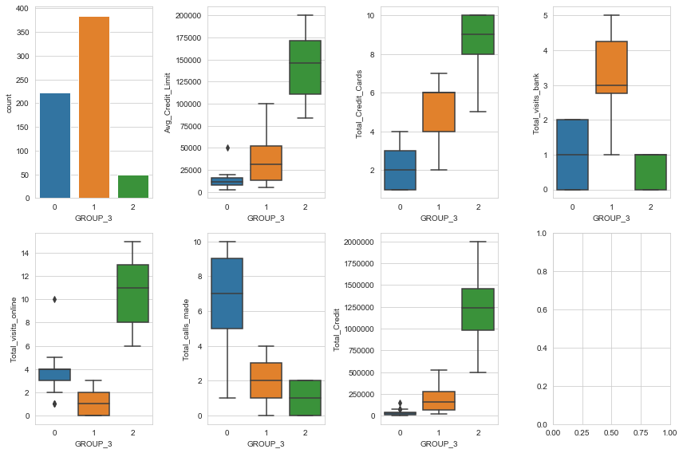

```python
model_kmeans_3 , prediction_kmeans_3 = analyze_kmeans(3 ,"GROUP_3")
```

```
******* k = 5  Kmeans *******
silhoutte score =0.33620

GROUP_5                      0            1         2          3          4
Avg_Credit_Limit     19,621.85   141,877.55 12,142.20  61,025.64  23,348.68
Total_Credit_Cards        5.49         8.80      2.38       5.62       5.41
Total_visits_bank         2.47         0.61      0.93       3.03       4.57
Total_visits_online       1.04        10.88      3.59       0.88       1.05
Total_calls_made          2.08         1.04      6.92       2.02       1.97
Total_Credit        106,319.33 1,242,448.98 29,431.19 340,316.24 126,447.37
```

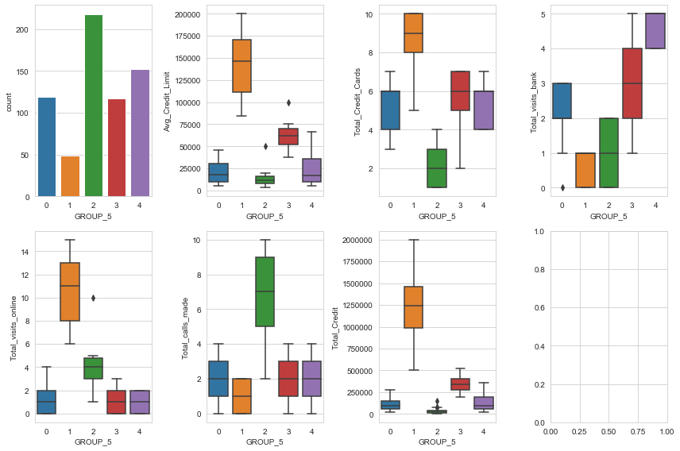

```python
model_kmeans_5 , prediction_kmeans_5  =analyze_kmeans(5 ,"GROUP_5")
```

```python
pd.crosstab(index = cc_df['GROUP_3'], rownames =['GROUP_3'], colnames = ['GROUP_5'], columns =cc_df['GROUP_5'])
```

| GROUP_5 GROUP_3 | 0 | 1 | 2 | 3 | 4 |
| --- | --- | --- | --- | --- | --- |
| 0 | 4 | 0 | 218 | 0 | 0 |
| 1 | 115 | 0 | 0 | 117 | 152 |
| 2 | 0 | 49 | 0 | 0 | 0 |

We can see that when we move from k=3 to k=5 the

** k=3, Group 2 == k=5 Group 1

** k=3, Group 0 == k=5 , Group 2

And what is interesting :

** k= 3 Group 1 is broken equally between k=5 , Group 0,3,4

### 4. Execute hierarchical clustering (with different linkages) with the help of dendrogram

### and cophenetic coeff. Analyse clusters formed using boxplot (15 marks)

```python
from sklearn.cluster import AgglomerativeClustering
from scipy.cluster.hierarchy import cophenet, dendrogram, linkage
from scipy.spatial.distance import pdist  #Pairwise distribution between data points
```

```python
def analyze_hierarchical(method , metric , y =None ):

    print(f'******* {method} {metric}   Dendogram *******')

    #dendogram
    Z = linkage(scaled_df, method=method , metric=metric)
    c, _ = cophenet(Z , pdist(scaled_df))

    print(f'cophenet index ={c:5.5f}')
    print()

    plt.figure(figsize=(10, 5))
    plt.title('Agglomerative Hierarchical Clustering Dendogram')
    plt.xlabel('sample index')
    plt.ylabel('Distance')
    dendrogram(Z,leaf_rotation=90.0,p=8,color_threshold=52,leaf_font_size=10,truncate_mode='lastp')
    if y is not None:
        plt.axhline(y=y, color='r', linestyle='--')

    plt.tight_layout()
    plt.show()
    return c

def analyze_hierarchical_model(k , label ,  affinity,  linkagex, cophenet):
    global df_cluster
    final_model=AgglomerativeClustering(n_clusters=k, affinity=affinity,  linkage=linkagex)
    final_model.fit(scaled_df)
    prediction=final_model.labels_

    # Silhoutte score
    score = silhouette_score(scaled_df, prediction)
    print(f'silhoutte score ={score:5.5f}')
    print()

    df_cluster=df_cluster.append({'type':'Hierarchical','number_clusters':k,'linkage':linkagex,'silhoute_score':score
                       ,'inertia':None,'cophenetic_index':cophenet}, ignore_index = True)

    #Append the prediction
    cc_df[label] = prediction
    cc_df[label] = cc_df[label].astype('category')
    print(cc_df.groupby(by = label).mean().T)
    print()
    #Plots
    fig, axs = plt.subplots(2,4, figsize=(12,8) )
    sns.countplot(x = label , data = cc_df, ax = axs[0,0])
    sns.boxplot( y = 'Avg_Credit_Limit', x = label , data = cc_df , ax = axs[0,1])
    sns.boxplot( y = 'Total_Credit_Cards', x = label , data = cc_df , ax = axs[0,2])
    sns.boxplot( y = 'Total_visits_bank', x = label , data = cc_df , ax = axs[0,3])
    sns.boxplot( y = 'Total_visits_online', x = label , data = cc_df , ax = axs[1,0])
    sns.boxplot( y = 'Total_calls_made', x = label , data = cc_df , ax = axs[1,1])
    sns.boxplot( y = 'Total_Credit', x = label , data = cc_df , ax = axs[1,2])
    fig.tight_layout()
    plt.show()
    #return ( final_model , prediction ,score )
```

```
******* ward euclidean   Dendogram *******
cophenet index =0.77004
```

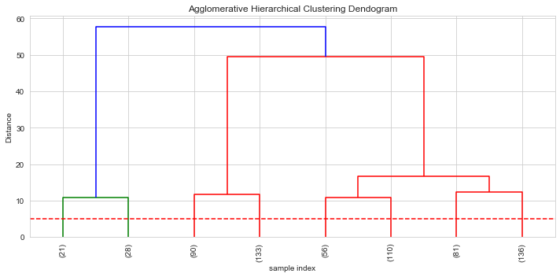

```
silhoutte score =0.22407

H_ward_6                       0          1          2         3         4  \
Avg_Credit_Limit      141,877.55  54,927.71  19,029.41 12,390.98 15,481.48
Total_Credit_Cards          8.80       5.57       5.34      2.37      5.70
Total_visits_bank           0.61       3.20       4.43      0.87      2.48
Total_visits_online        10.88       0.95       1.10      3.68      0.83
Total_calls_made            1.04       2.01       2.15      8.14      1.74
Total_Credit        1,242,448.98 303,692.77 102,823.53 30,142.86 86,962.96

H_ward_6                    5
Avg_Credit_Limit    11,811.11
Total_Credit_Cards       2.49
Total_visits_bank        1.04
Total_visits_online      3.39
Total_calls_made         4.92
Total_Credit        29,500.00
```

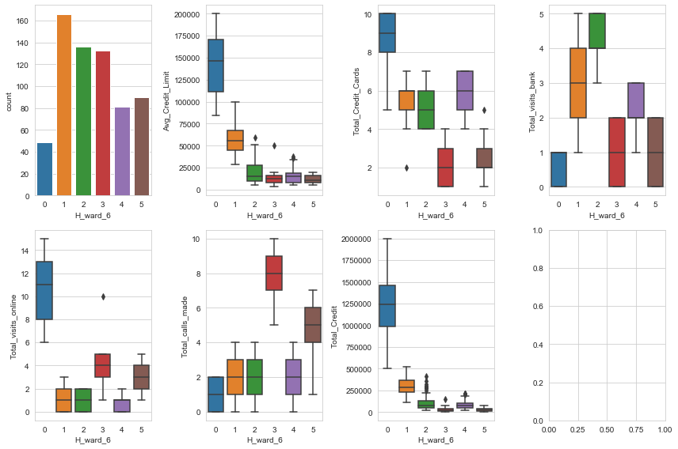

```python
cop = analyze_hierarchical('ward','euclidean',5)
analyze_hierarchical_model( 6 , 'H_ward_6','euclidean','ward', cop)
#linkage : {"ward", "complete", "average", "single"}
```

```
******* ward euclidean   Dendogram *******
cophenet index =0.77004
```

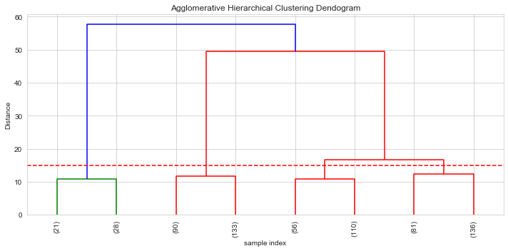

```
silhoutte score =0.34663

H_ward_4                    0            1         2          3
Avg_Credit_Limit    17,705.07   141,877.55 12,156.95  54,927.71
Total_Credit_Cards       5.47         8.80      2.42       5.57
Total_visits_bank        3.71         0.61      0.94       3.20
Total_visits_online      1.00        10.88      3.56       0.95
Total_calls_made         2.00         1.04      6.84       2.01
Total_Credit        96,903.23 1,242,448.98 29,883.41 303,692.77
```

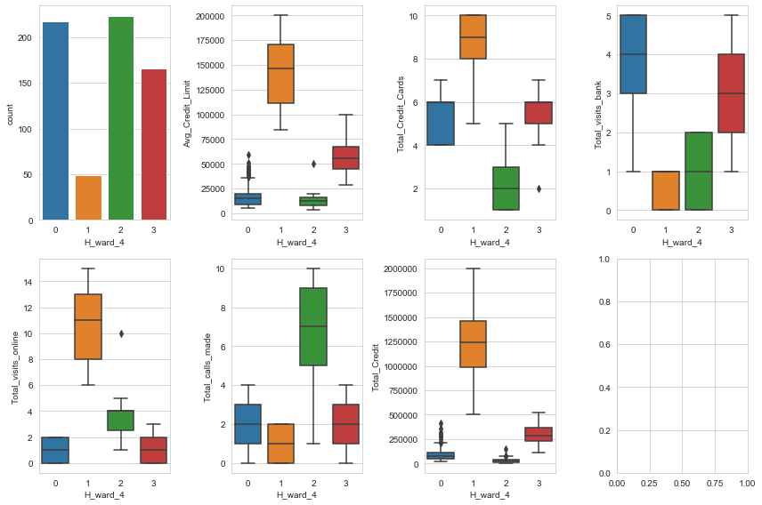

```python
cop = analyze_hierarchical('ward','euclidean',15)
analyze_hierarchical_model( 4 , 'H_ward_4','euclidean','ward', cop)
#linkage : {"ward", "complete", "average", "single"}
```

```
******* complete euclidean   Dendogram *******
cophenet index =0.90161
```

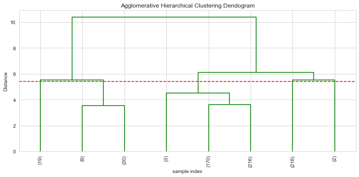

```
silhoutte score =0.47810

H_complete_5                 0          1            2         3          4
Avg_Credit_Limit     33,493.57 107,105.26   166,103.45 12,000.00  75,000.00
Total_Credit_Cards        5.49       9.11         8.72      2.38       4.00
Total_visits_bank         3.45       0.74         0.55      0.94       0.00
Total_visits_online       1.00      10.42        11.17      3.56      10.50
Total_calls_made          2.02       1.11         0.97      6.93       5.50
Total_Credit        184,316.20 969,894.74 1,446,620.69 28,962.96 325,000.00
```

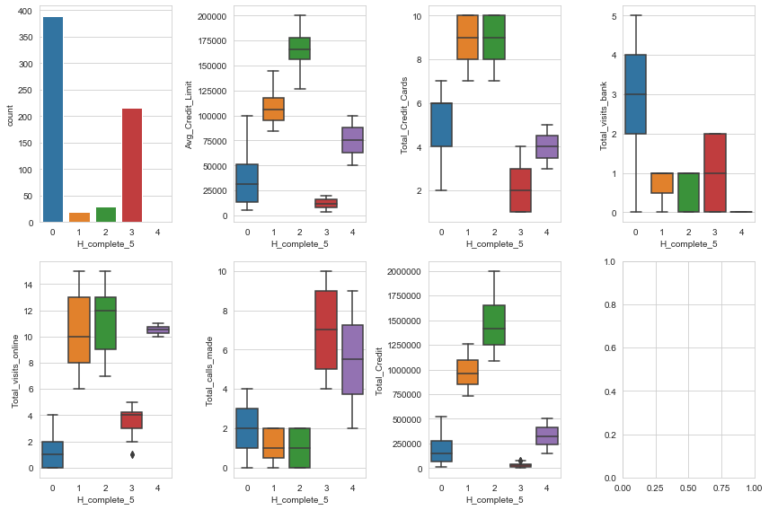

```python
cop = analyze_hierarchical('complete','euclidean',5.4)
analyze_hierarchical_model( 5 , 'H_complete_5','euclidean','complete',cop)
#linkage : {"ward", "complete", "average", "single"}
```

```
******* average euclidean   Dendogram *******
cophenet index =0.90921
```

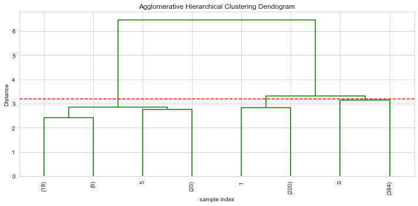

```
silhoutte score =0.50828

H_average_3                  0            1         2
Avg_Credit_Limit     33,698.70   141,877.55 12,203.62
Total_Credit_Cards        5.51         8.80      2.40
Total_visits_bank         3.48         0.61      0.93
Total_visits_online       0.98        10.88      3.57
Total_calls_made          2.01         1.04      6.86
Total_Credit        185,724.68 1,242,448.98 29,868.78
```

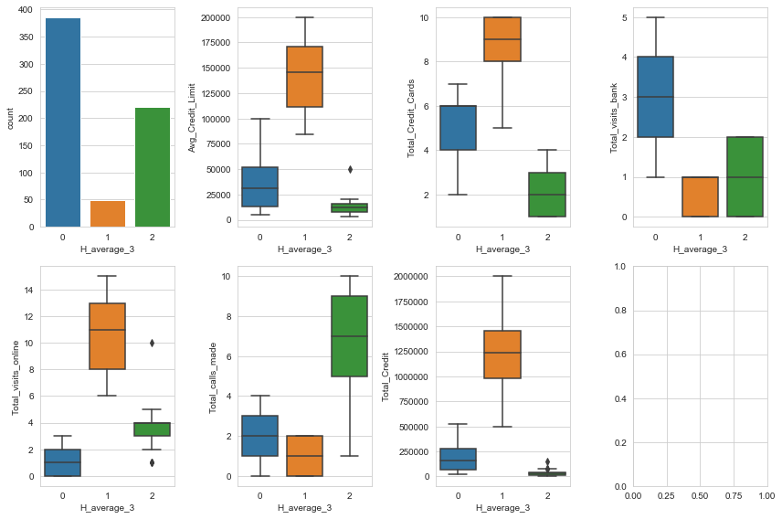

```python
cop = analyze_hierarchical('average','euclidean',3.2)
analyze_hierarchical_model(3 , 'H_average_3','euclidean','average',cop)
#linkage : {"ward", "complete", "average", "single"}
```

```
******* single euclidean   Dendogram *******
cophenet index =0.79815
```

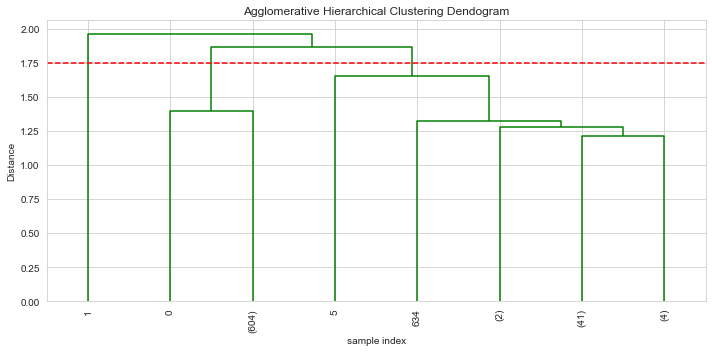

```
silhoutte score =0.36958

H_single_3                     0          1          2
Avg_Credit_Limit      141,877.55  50,000.00  25,819.83
Total_Credit_Cards          8.80       3.00       4.38
Total_visits_bank           0.61       0.00       2.55
Total_visits_online        10.88      10.00       1.92
Total_calls_made            1.04       9.00       3.77
Total_Credit        1,242,448.98 150,000.00 128,851.24
```

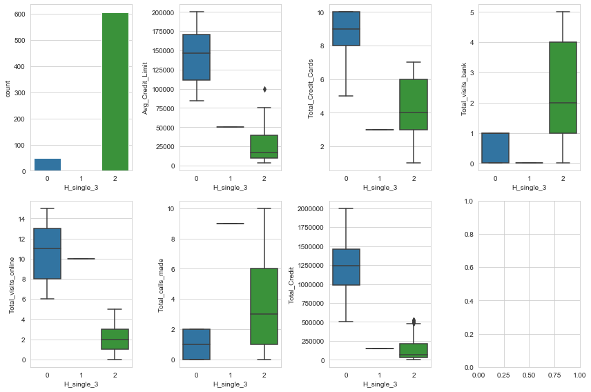

```python
cop = analyze_hierarchical('single','euclidean',1.75)
analyze_hierarchical_model(3 , 'H_single_3','euclidean','single', cop)
#linkage : {"ward", "complete", "average", "single"}
```

```python
df_cluster
```

|  | type | number_clusters | linkage | silhoute_score | inertia | cophenetic_index |
| --- | --- | --- | --- | --- | --- | --- |
| 0 | KMeans | 3 | None | 0.51 | 1,034.45 | None |
| 1 | KMeans | 5 | None | 0.34 | 786.41 | None |
| 2 | Hierarchical | 6 | ward | 0.22 | None | 0.77 |
| 3 | Hierarchical | 4 | ward | 0.35 | None | 0.77 |
| 4 | Hierarchical | 5 | complete | 0.48 | None | 0.90 |
| 5 | Hierarchical | 3 | average | 0.51 | None | 0.91 |
| 6 | Hierarchical | 3 | single | 0.37 | None | 0.80 |

From the above it appears that

- KMeans k=3
- Hierarchial/average/k=3

are good clustering.

Let's analyze these

```python
labels = ['Avg_Credit_Limit','Total_Credit_Cards','Total_visits_bank','Total_visits_online','Total_calls_made','Total_Credit']
groupby_1 = cc_df.groupby(by = 'GROUP_3')
print(groupby_1['Avg_Credit_Limit'].count().T)
print()
print(groupby_1[labels].mean().T)

print()

groupby_2 = cc_df.groupby(by = 'H_average_3')
print(groupby_2['Avg_Credit_Limit'].count().T)
print()
print(groupby_2[labels].mean().T)
print()
```

```
GROUP_3
0    222
1    384
2     49
Name: Avg_Credit_Limit, dtype: int64

GROUP_3                     0          1            2
Avg_Credit_Limit    12,180.18  33,768.23   141,877.55
Total_Credit_Cards       2.41       5.52         8.80
Total_visits_bank        0.94       3.48         0.61
Total_visits_online      3.57       0.98        10.88
Total_calls_made         6.85       2.01         1.04
Total_Credit        29,860.36 186,135.42 1,242,448.98

H_average_3
0    385
1     49
2    221
Name: Avg_Credit_Limit, dtype: int64

H_average_3                  0            1         2
Avg_Credit_Limit     33,698.70   141,877.55 12,203.62
Total_Credit_Cards        5.51         8.80      2.40
Total_visits_bank         3.48         0.61      0.93
Total_visits_online       0.98        10.88      3.57
Total_calls_made          2.01         1.04      6.86
Total_Credit        185,724.68 1,242,448.98 29,868.78
```

### It is obvious from the above comparision that both Hierarchial and Kmeans are able to cluster the customers into 3 different groups :

- Group 1 [2 in KNN, 1 in Hierarchial]

High Credit limit, Many Cards , Interact Online only

- Group 2 [ 0 in KNN , 2 in Hierarchial ]

Low Credit Limit , Few Credit Cards , They mostly interact through phone but also prefer online

- Group 3 [ 1 in KNN , 0 in Hierarchial ]

Recommendation:

- If the Bank wants to get customers with High Credit , it needs to make online service better
- Making online better will also help the Low Credit Customers as they also use online ( second preference as compaired to telephone)
- The Medium Credit Customers are the customers who come to the bank most. They hardly use online. This can also mean that the features they need are not avaiable online. The Bank has most of its customers in Low and Medium credit. There has to be a reason why Medium credit customers have to come to the bank while the low credit can use both phone or online.

Improving online service will positively impact everyone. Its seems right now online is focussed only to tthe experience/needs of high credit

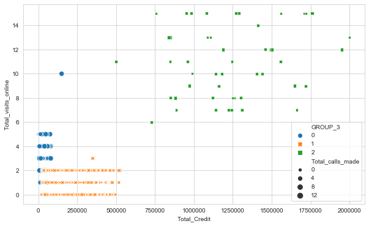

```python
fig, ax1 = plt.subplots(1,1, figsize = (10,6))
sns.scatterplot(x='Total_Credit'
                , y = 'Total_visits_online'
                , hue = 'GROUP_3'
                ,style  ='GROUP_3'
                , size = 'Total_calls_made'
                , data = cc_df
               , ax = ax1)
```